# Tangi across three UTMBs

Where a 2026-calibre run by Tangi Taton would have landed in the 2024 and 2025 editions — and how much of the answer is really knowable.

Author

Alexis Konarski

Published

September 8, 2026

# The question

Tangi Taton (bib 535, UTMB Index **758**) finished **UTMB 2026** in **26:26**, **153rd** of 1,671 finishers (category 20-34M). How would the *same runner, running equally well*, have placed in the **2024** and **2025** editions?

Neither finish time nor raw rank answers this: each year a different field turns up on a different day. The decisive fact is that **2026 was an unusually deep edition at his level** — 132 higher-rated runners reached the finish, against 93 in 2024 and 80 in 2025. The same run is worth fewer places when more strong runners are in the way, so ranks have to be adjusted for field strength before they can be compared across years.

The question is a conditional one: *if he had run the same race relative to his rating*, what would that have been worth in a thinner field? “Running equally well” is an assumption imposed here, not a prediction — nobody knows what he would actually have done on a different mountain day. What follows works that assumption through, and then sets out how much weight it can bear.

# How would he have finished?

| Edition | Finishers | Higher-rated finishers | Projected place | Across the three methods | Places gained on his 153rd |
| --- | --- | --- | --- | --- | --- |
| 2024 | 1,760 | 93 | 110th | 107th–114th | +43 |
| 2025 | 1,653 | 80 | 95th | 90th–101st | +58 |

The same run puts him around **110th in 2024** and **95th in 2025** — roughly 43 and 58 places ahead of his real 153rd. Three different ways of doing the arithmetic (set out below) land within 11 places of each other.

That closeness is reassuring about the arithmetic and nothing more. The three methods share one input — his single 2026 race — so they cannot disagree about it, and **their spread is not an uncertainty interval**. What can be said about precision is set out further down; the short version is that the place should be read to the nearest ten or twenty, not to the unit. 19 finishers sit within a quarter of an hour of his projected 2024 time and 6 within a quarter of an hour in 2025, so a 15-minute error in the modelling is worth a dozen places on its own.

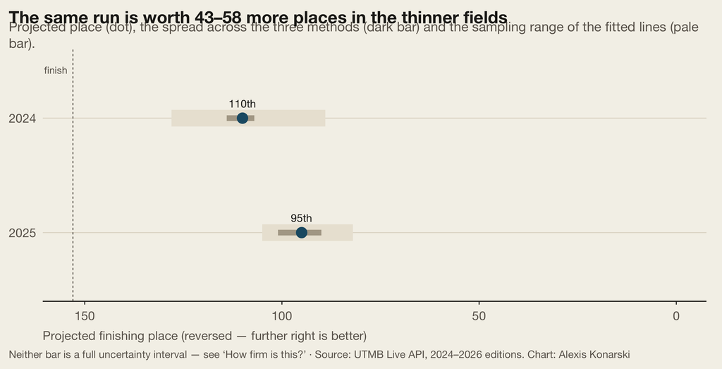

The projected place in each prior edition, against Tangi’s real 2026 finish. Further right is better.

# What his 2026 run was actually worth

Before his run can be carried anywhere it has to be valued correctly — and the obvious way of valuing it is wrong.

The obvious way is to compare where he was seeded with where he finished. On the 2026 start list a 758 index put him **229th**; he finished **153rd**, apparently *beating* his seed by 76 places. That comparison is broken, and the way it is broken flatters every finisher.

The seed counts everyone rated above him who **started**; the rank counts only those who **finished**. 711 runners left the denominator without leaving the numerator, so every finisher shows a positive margin by construction. Across all 1,671 2026 finishers the median “margin” is **249 places**; Tangi’s 76 is only the **28th percentile** of it.

Put both sides on the same basis — seed among finishers, rank among finishers — and the margin reverses:

| Basis | Seed | Finish | Margin | Percentile of the field |
| --- | --- | --- | --- | --- |
| Seed on the start list (mixed basis) | 229th | 153rd | +76 places | 28th |
| Seed among finishers (like for like) | 133rd | 153rd | -20 places | 43rd |

Of that apparent +76-place margin, **96 places came from higher-rated runners dropping out ahead of him** — attrition, not racing. On a like-for-like basis he finished **20 places behind his rating** among those who finished, against a field median of **+7**. He ran an unremarkable race for his rating: solidly, but not above it.

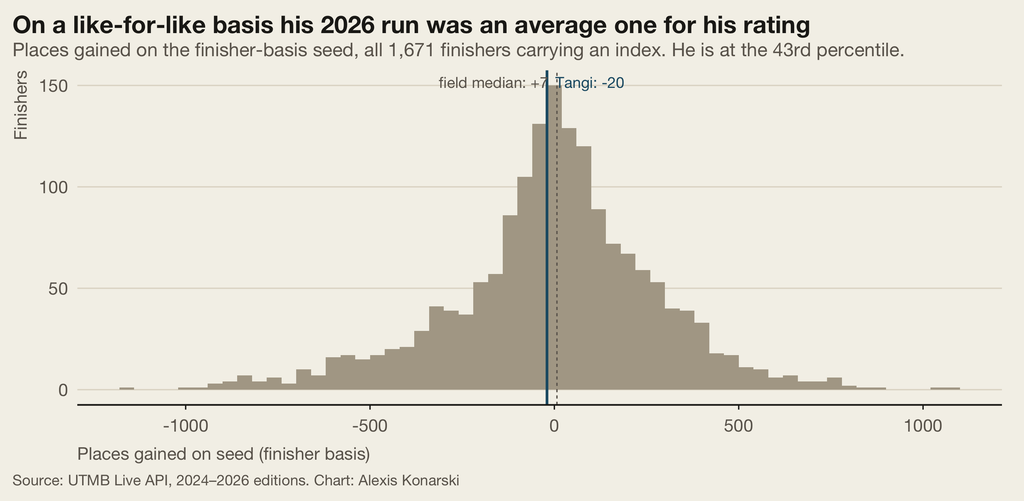

The distribution of the like-for-like margin (seed among finishers minus finishing rank) across all 2026 finishers. Positive = finished ahead of rating.

This does not change the direction of the answer, but it changes what is being carried across the years. What gets transplanted below is **an average run for a 758 index**, not an outstanding one, and the reason he places better in 2024 and 2025 is entirely that the field was thinner — not that he had a special day.

# The lenses

Four lenses, from naïve to working. Every projected rank is a rank **among finishers**, and every seed is counted **among finishers**, so the two are always on the same basis.

**A · Seed — “on paper”.** Count the higher-rated runners in each year’s field. Among finishers that is **94th** (2024), **81st** (2025) and **133rd** (2026). This is expectation, not result, but it is the crux of the question: same runner, better starting position, because fewer strong runners were in his way.

**B · Raw time — the naïve answer.** Slot 26:26 straight into each year’s finish list: 77th in 2024, 75th in 2025. Distrust it — it assumes identical conditions across years, when a typical 758-index finisher needed 71 min longer in 2024 than in 2026. Its swing measures the size of the year effect, not a projection.

**C · Seed-adjusted — his rating, plus his form.** Carry his measured like-for-like form ($\delta_F = -20$ places, or equivalently $\rho_F = 1.15\times$ his seed) onto each year’s own finisher-basis seed. That gives **101st–93rd in 2025** and **114th–108th in 2024**.

**D · Index-residual time model.** Fit each edition’s UTMB Index → finish-time line over the well-measured index range (650–900). In 2026 a typical 758-index finisher took **27:13**; Tangi ran **47 min faster**. Holding that margin and reading it against each year’s own line puts him at **90th in 2025** and **107th in 2024**.

C and D are **not independent**. Both are anchored on the same single run and the same index; they differ only in whether the anchor is expressed in places or in minutes. Their agreement is reassuring about arithmetic, not about the underlying assumption.

Every lens, every edition. The 2026 row is a self-check: C reproduces his actual 153rd by construction, and D lands on it because his residual is measured there.

| Edition | A · seed | B · raw time | C · delta | C · ratio | D · time model | D · full-range fit |
| --- | --- | --- | --- | --- | --- | --- |
| 2024 | 94th | 77th | 114th | 108th | 107th | 125th |
| 2025 | 81st | 75th | 101st | 93rd | 90th | 94th |
| 2026 | 133rd | 153rd | 153rd | 153rd | 153rd | 153rd |

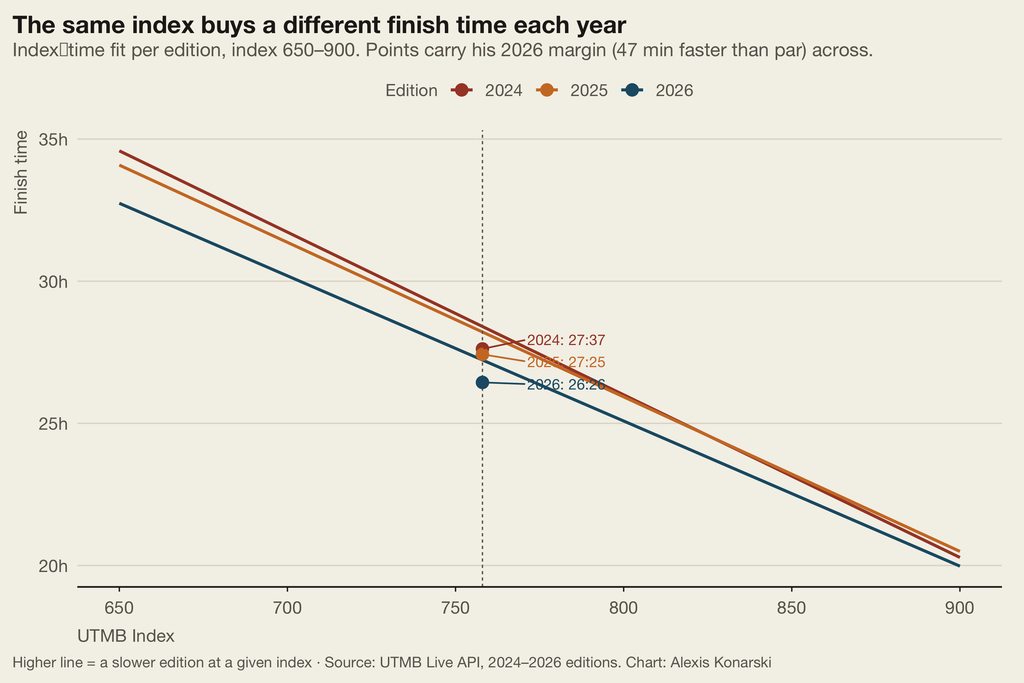

Each edition’s UTMB Index → finish-time line, fit over the well-measured index range. The vertical line marks Tangi’s index; the points are his projected times once his 2026 margin is carried across.

# How firm is this?

Four things bound how precisely this can be answered. None of them changes the direction; all of them argue against quoting a place to the unit.

**The margin being carried is thin.** Everything rests on one number: that Tangi ran 47 min faster than a typical 758-index finisher in 2026. Against a residual spread of 220 min around that line, this is a **z of -0.22** — about a fifth of a standard deviation. Measured on a single race, that is close to indistinguishable from an ordinary day, so the honest reading is not “he has a 47 min edge” but “he ran roughly to his rating, perhaps a shade better”. Carry *exactly* his rating instead — set the margin to zero — and he lands 133rd in 2024 and 112th in 2025, some 26 and 22 places back. That is the size of the entire personal-margin term.

**The lines themselves are estimates.** Lens D reads his margin against two fitted index→time lines, each carrying sampling error of its own. Bootstrapping both fits (600 replicates) puts him at 89th–128th in 2024 and 82nd–105th in 2025 — already several times wider than the three methods disagree, and covering only one source of error.

**Places are cheap where he finishes.** 19 finishers sat within a quarter of an hour of his projected 2024 time and 6 within a quarter of an hour in 2025. Fifteen minutes is well inside the noise of any of this, and it is worth a dozen places.

**And he might not have finished at all.** 36% of 2024 starters and 33% of 2025 starters did not, both above 2026’s 30%. Every number here is conditional on him reaching Chamonix.

Read together, the defensible answer is a region rather than a place: **roughly 85th–135th in 2024 and 80th–115th in 2025**, comfortably ahead of 153rd in both — and the reason is the field rather than the runner.

# Why the years differ: field and attrition

Field depth at and above Tangi’s index (758). The first two columns are the same population on the two bases used throughout; the last three are start-list counts.

| Edition | Higher-rated starters | Higher-rated finishers | Starters ≥ 800 | Starters ≥ 850 | Starters ≥ 900 |
| --- | --- | --- | --- | --- | --- |
| 2024 | 170 | 93 | 96 | 47 | 10 |
| 2025 | 153 | 80 | 77 | 36 | 9 |
| 2026 | 228 | 132 | 137 | 60 | 24 |

In 2026, **132** higher-rated runners reached the finish; in 2024 and 2025 only **93** and **80** did. The elite tail says the same — 24 starters rated ≥ 900 in 2026 against 10 and 9. Tangi did not get slower; the company got faster.

That said, a thin field above him is not a floor under his rank. **In 2026, 43 of the 152 finishers ahead of him (28%) were rated at or below him.** Finishing rank is not bounded by higher-rated finishers: to be 153rd in 2024 he would need 59 lower-rated finishers ahead of him out of 1,667 available, which is entirely possible. A thin field above him makes a better placing the *expectation*, not a certainty — which is why the projected place is best read as a region.

| Edition | Starters | Finishers | DNF rate | Median index | Par time at 758 |
| --- | --- | --- | --- | --- | --- |
| 2024 | 2,750 | 1,760 | 36% | 545 | 28:24 |
| 2025 | 2,471 | 1,653 | 33% | 537 | 28:12 |
| 2026 | 2,382 | 1,671 | 30% | 558 | 27:13 |

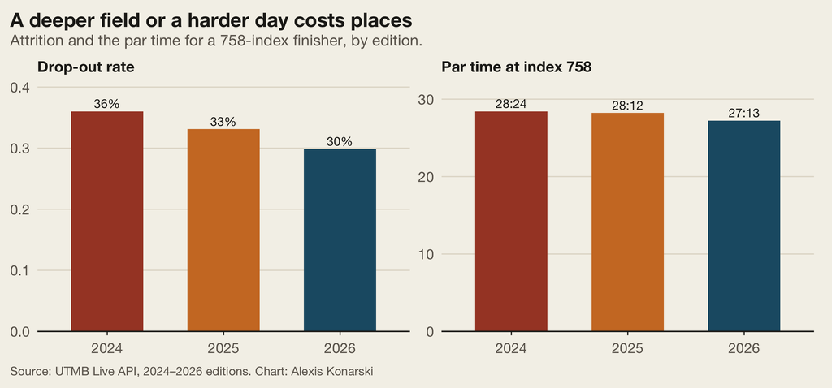

Left: share of starters who did not finish. Right: the finish time a typical 758-index runner posted each year.

**Does a changed course break C and D?** For a *uniform* change — one that slows everyone by roughly the same amount — no, and this is testable rather than assumed. If the year effect were uniform, the index→time slope would be the same in every edition and only the intercept would move. It essentially does: -3.43, -3.26 and -3.06 min per index point over the fitted range, differences well inside the noise. A formal test for an index × edition interaction gives **p = 0.39** over the fitted range and **p = 0.90** over the whole field. The year effect really is a clean level shift, which is exactly the shape C and D assume — a point in their favour, and one worth testing rather than asserting.

**What they do not absorb.** Three things. A *non-uniform* course change would reshuffle who is fast and break both. A change in the **index scale** between editions shifts the x-axis rather than the line, and lens D does not see it — that is dealt with below. And **who finishes** differs by year (DNF rate 36% / 33% / 30%), which truncates the slow tail differently and moves the very intercept D reads; restricting the fit to index 650–900 limits but does not eliminate this.

# Is a 758 in 2026 a 758 in 2024?

The whole exercise drops a **2026-vintage** index into fields rated on the **2024 and 2025** scales. That is only legitimate if the scale has not moved.

The scrape does return each edition’s contemporaneous index rather than today’s value — among runners matched across 2024 and 2026, only **1.4%** carry an identical number. So the scale can drift, and it does. Measured within runner on those who ran two editions, the median index rose **+9 points from 2024 to 2026** (n = 217) and **+13 points from 2025 to 2026** (n = 174). At 3.1 min per point, ten points is about half an hour of finish time — not a rounding error.

Two things keep this from overturning the answer.

**It is a known quantity, and correcting for it moves him a little.** Expressing his 758 on each year’s own scale — 749 for 2024, 745 for 2025 — gives seeds of 105th and 94th among finishers instead of 94th and 81st, and moves lens C to 125th (2024) and 114th (2025) — some 11 and 13 places worse. Both remain comfortably ahead of 153rd, and both sit inside the region set out under How firm is this?. Note also that returnees are a selected sample — runners who come back and get re-rated tend to be improving — so this correction is an **upper bound** on pure scale inflation, not a best estimate.

**His own ratings say most of the rise was real.** Tangi’s UTMB Index on race day 2025 was **732**, against 758 in 2026: **+26 points** in a year, where the population drifted **+13**. At most half of his own improvement can be scale; the rest is a genuinely stronger runner. The counterfactual this report projects — a 2026-calibre Tangi in the 2025 field — is therefore a materially better runner than the 2025-vintage one, whether the comparison is made at 758 or at the drift-adjusted 745.

Sensitivity of the finisher-basis seed to the index scale. The drift-adjusted row uses each year’s own median returnee drift.

| His index treated as | 2024 seed | 2025 seed | 2026 seed |
| --- | --- | --- | --- |
| 732 (his actual 2025 rating) | 133rd | 108th | 175th |
| 745 / 749 (drift-adjusted) | 105th | 94th | 133rd |
| 758 (2026 value, as used) | 94th | 81st | 133rd |

# Bottom line

- **2024**: about 110th (107th–114th across the three methods) — some 43 places ahead of his real 153rd, in a field of 1,760 finishers.
- **2025**: about 95th (90th–101st across the three methods) — some 58 places ahead of his real 153rd, in a field of 1,653 finishers.

Run the same race in 2024 or 2025 and Tangi finishes around 110th and 95th respectively — some 43 to 58 places better than his real 153rd. The cause is the field, not the runner: 2026 brought 132 higher-rated finishers to the line against 93 and 80 in those years. On a like-for-like basis his 2026 run was an ordinary one for a 758 index, and that ordinary run is what has been carried across.

# Methodology

Both working lenses transplant Tangi’s **2026 run** onto the 2024 and 2025 fields. His 2026 UTMB Index is $I_T = 758$; his real 2026 finish is $r_{26} = 153$ of 1,671 finishers. Each edition uses the full field (finishers + DNFs) restricted to runners carrying an index.

## Bases

Everything is counted **among finishers**:

$$\text{seed}_y = 1 + \#\{\, i \in \text{finishers}_y : I_i > I_T \,\}.$$

Mixing a starter-basis seed with a finisher-basis rank is the error diagnosed in the form section: it removes 711 runners from the denominator but not the numerator and awards every finisher a spurious positive margin (median 249 places).

## C · Seed-adjusted (rank-based)

Form, measured like for like in 2026:

$$\rho_F = \frac{r_{26}}{\text{seed}_{26}} = \frac{153}{133} = 1.15,
\qquad
\delta_F = \text{seed}_{26} - r_{26} = -20\ \text{places},$$

projected as $\hat r^{\,\rho}_y = \rho_F \times \text{seed}_y$ and $\hat r^{\,\delta}_y = \text{seed}_y - \delta_F$. C uses only ranks and ratings, never a clock, so any change that slows the whole field equally leaves it untouched by construction. Its assumptions: the index is comparable across editions (tested); form is a stable personal trait (imposed by the question rather than tested — see How firm is this?); and the seed→finish relationship keeps a similar shape.

**Robustness — is the finisher-basis seed a fluke of who dropped?** Fitting a per-edition logistic model of finishing on a natural spline in index and summing the fitted probabilities over the higher-rated starters gives the *expected* number of higher-rated finishers:

| Edition | Higher-rated starters | Expected to finish | Actually finished |
| --- | --- | --- | --- |
| 2024 | 170 | 90.0 | 93 |
| 2025 | 153 | 80.4 | 80 |
| 2026 | 228 | 135.5 | 132 |

The realised counts sit within a few runners of the modelled expectation in every edition, so the between-year differences in seed reflect the composition of the field rather than a lucky or unlucky pattern of drop-outs.

## D · Index-residual time model

Fit $\widehat{\text{time}}_y(I) = a_y + b_y I$ on year $y$’s finishers, take his personal margin $\varepsilon = \text{time}_T - \widehat{\text{time}}_{26}(I_T)$, which is 47 min faster than par, and rank $\hat t_y = \widehat{\text{time}}_y(I_T) + \varepsilon$ against that year’s finishers.

**Range restriction.** The fit uses index 650–900 rather than the whole field. Below that range the sample is heavily truncated by the cut-off and the truncation differs by year (DNF rate 36% / 33% / 30%), which flattens the bottom of the line and biases exactly the intercept D reads. The effect is material: over the full range the par time at 758 is 29:09 (2024) against 27:36 (2026), a gap of 93 min; restricted, it is 28:24 against 27:13, a gap of 71 min. Roughly a quarter of the apparent “2024 was a slower year” signal is selection. The full-range projections are shown alongside the restricted ones in the lens table; they differ by 18 places in 2024 and 4 in 2025.

**Assumption.** $\varepsilon$ is constant in absolute hours. If a year were much harder, a strong runner’s absolute advantage might grow, which D would under-count — so D is, if anything, slightly conservative in the hardest year. Fit quality: $R^2 \approx 0.43$ over the restricted range, against 0.74 over the whole field — the drop is range attenuation, not a worse model, and Tangi sits in the middle of the fitted range.

## The reported range, and what it is not

The range in the headline table is the **spread across the three methods** (C-delta, C-ratio, D). It is reported because it shows the arithmetic is not knife-edged, and it is explicitly **not** a confidence interval: three deterministic recipes sharing a single input cannot disagree about that input, so their agreement measures nothing about how well the input is known.

The uncertainty that *can* be quantified from this data is sampling error in the two fitted lines behind lens D. Bootstrapping both fits over the restricted range (600 replicates, resampling finishers with replacement) gives 89th–128th for 2024 and 82nd–105th for 2025 — several times the spread across methods, and still only one term. The others are set out in How firm is this?: the thinness of the transplanted margin (a zero-margin run costs him 26–22 places), the density of finishers around his projected time, and the chance of not finishing at all. None is folded into a single published interval, because doing so would require assuming a distribution for the one quantity — his form on a day he did not run — that is genuinely unknown.

## What is excluded

Raw time (B) is reported but not used: it is blind to conditions and to any course change, and it implies he would have finished 77th in 2024 — better than every field-strength-aware lens — purely because 2024 was a slower year. Seed (A) is reported as the input to C. A *non-uniform* course change — a materially more technical or higher route — would break both working lenses; across 2024–2026 UTMB ran essentially the same classic loop (173.6 km reconstructed in 2026 against 176.7 km in 2024 and 175.4 km in 2025), so this is treated as second-order.